# ANTsPyMM: Blind Image Quality Control (QC) Summary

Automated Analysis

2025-06-19

### 1. Introduction

This report demonstrates the `antspymm.blind_image_assessment` function for performing automated, no-reference Quality Control on medical images. We will first simulate a set of images with varying characteristics (noise, smoothness, etc.) and then run the QC analysis on them. The results are presented in interactive and static tables.

### 2. Simulating Images for QC

First, we set up a Python environment and generate several test images. A temporary directory is created to store these images, ensuring the script does not leave files on the system.

```python
# --- Python Environment and Image Simulation ---
import siq
import ants
import antspymm
import os
import tempfile
import shutil
import pandas as pd

# Create a single, system-agnostic temporary directory for all output files.
# This makes the script portable (works on Linux, macOS, Windows).
temp_dir = tempfile.mkdtemp()
print(f"Using temporary directory: {temp_dir}")
```

```
## Using temporary directory: /tmp/tmp0lt08_m8
```

```python
# List to hold the paths of all generated files for processing.
generated_files = []

# --- Image 1: Baseline Simulated Image ---
print("Simulating baseline image...")
```

```
## Simulating baseline image...
```

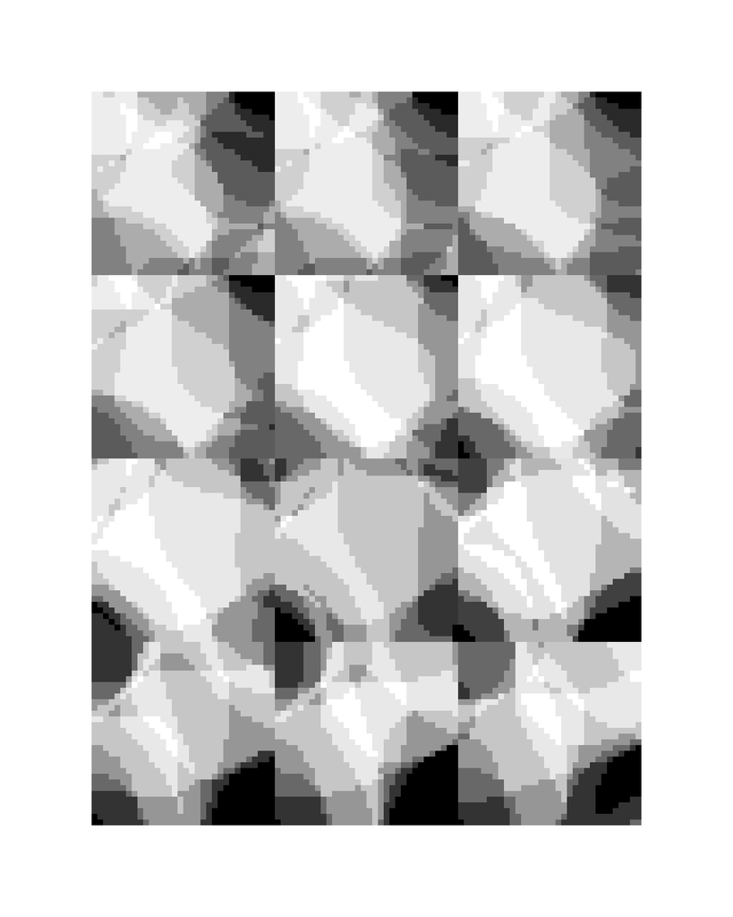

```python
eximg = siq.simulate_image()
exfn_base = os.path.join(temp_dir, 'baseline.nii.gz')
ants.image_write(eximg, exfn_base)
ants.plot( eximg )
```

```python
generated_files.append(exfn_base)

# --- Image 2: Additive Gaussian Noise ---
print("Simulating image with Gaussian noise...")
```

```
## Simulating image with Gaussian noise...
```

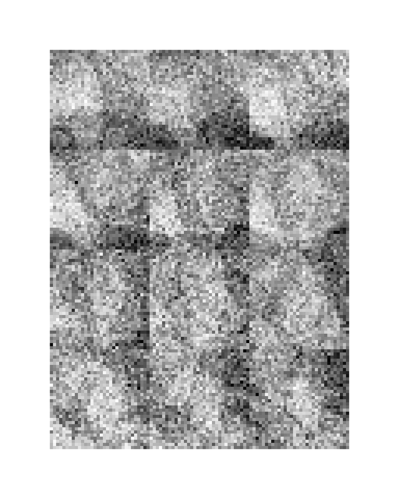

```python
img_gauss = siq.simulate_image().add_noise_to_image('additivegaussian', [0, 1])
exfn_gauss = os.path.join(temp_dir, 'noise_gaussian.nii.gz')
ants.image_write(img_gauss, exfn_gauss)
ants.plot( img_gauss )
```

```python
generated_files.append(exfn_gauss)

# --- Image 3: Salt & Pepper Noise ---
print("Simulating image with Salt & Pepper noise...")
```

```
## Simulating image with Salt & Pepper noise...
```

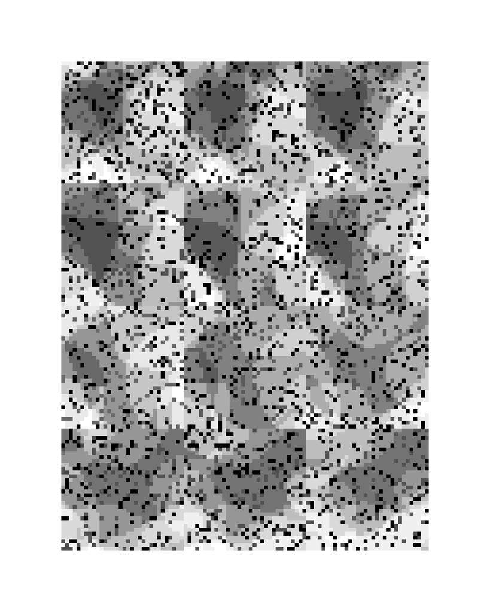

```python
img_sp = siq.simulate_image()
img_sp = ants.add_noise_to_image(img_sp, 'saltandpepper', [0.2, -1, 1])
exfn_sp = os.path.join(temp_dir, 'noise_saltpepper.nii.gz')
ants.image_write(img_sp, exfn_sp)
ants.plot( img_sp )
```

```python
generated_files.append(exfn_sp)

# --- Image 4: Smoothed Image ---
print("Simulating a smoothed image...")
```

```
## Simulating a smoothed image...
```

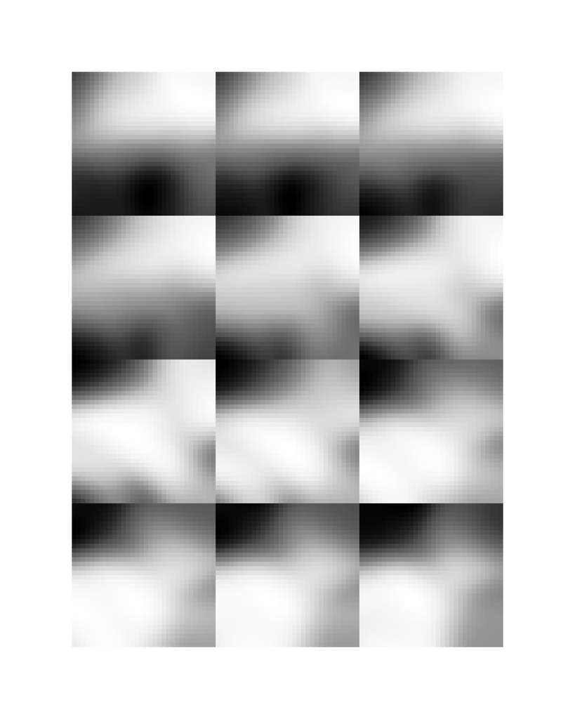

```python
img_smooth = siq.simulate_image().smooth_image(3)
exfn_smooth = os.path.join(temp_dir, 'smooth.nii.gz')
ants.image_write(img_smooth, exfn_smooth)
ants.plot( img_smooth )
```

```python
generated_files.append(exfn_smooth)

# --- Image 5: Time Series Image ---
print("Simulating a 4D time-series image...")
```

```
## Simulating a 4D time-series image...
```

```python
img_ts = siq.simulate_image([16, 16, 16, 4])
exfn_ts = os.path.join(temp_dir, 'timeseries.nii.gz')
ants.image_write(img_ts, exfn_ts)
generated_files.append(exfn_ts)

print(f"\nGenerated {len(generated_files)} files for analysis.")
```

```
##
## Generated 5 files for analysis.
```

### 3. Running Batch QC Analysis

Now we loop through the generated images and run `blind_image_assessment` on each. The results are collected into a single Pandas DataFrame.

```python
# --- Batch QC Processing ---
# A more efficient way to build a DataFrame is to append dictionaries to a
# list and then call the DataFrame constructor once.
qc_results = []
for f in generated_files:
    print(f"Running QC on: {os.path.basename(f)}...")
    myqc = antspymm.blind_image_assessment(f)
    qc_results.append(myqc)
```

```
## Running QC on: baseline.nii.gz...
## Running QC on: noise_gaussian.nii.gz...
## Running QC on: noise_saltpepper.nii.gz...
## Running QC on: smooth.nii.gz...
## Running QC on: timeseries.nii.gz...
```

```python
# Concatenate all results into a single DataFrame.
qcdf = pd.concat(qc_results, axis=0)

# The 'qcdf' DataFrame is now automatically available to R via reticulate as py$qcdf
# No need to write to a temporary CSV file.
```

### 4. QC Results

The following tables display the QC metrics for all simulated images.

#### 4.1. Interactive QC Data Table

This table is sortable and searchable, which is useful for exploring the results dynamically.

|  | filename | dimensionality | noise | snr | cnr | psnr | ssim | mi | reflection_err | EVR | msk_vol | spc0 | spc1 | spc2 | org0 | org1 | org2 | dimx | dimy | dimz | dimt | slice | modality | mriseries | mrimfg | mrimodel | mriMagneticFieldStrength | mriSAR | mriPixelBandwidth | … |
| --- | --- | --- | --- | --- | --- | --- | --- | --- | --- | --- | --- | --- | --- | --- | --- | --- | --- | --- | --- | --- | --- | --- | --- | --- | --- | --- | --- | --- | --- | --- |
| 1 | baseline | 3 | 0.03686962649226189 | 25.65216636657715 | 20.97955131530762 | 23.16455364227295 | 0.9420988563190617 | -1.022683305301708 | 0.1574717164039612 | 0.669921875 | 32494 | 1 | 1 | 1 | 0 | 0 | 0 | 32 | 32 | 32 | 1 | 0 | unknown |  |  |  |  |  |  | … |
| 2 | noise_gaussian | 3 | 0.09391368180513382 |  |  | 17.13407397270203 | 0.6414701515474558 | -0.2906219902310045 | 0.1369898468255997 |  | 0 | 1 | 1 | 1 | 0 | 0 | 0 | 32 | 32 | 32 | 1 | 0 | unknown |  |  |  |  |  |  | … |
| 3 | noise_saltpepper | 3 | 0.07676166296005249 |  |  | 14.11953449249268 | 0.5466637131464198 | -0.7279380190226191 | 0.2087989449501038 | 0.833984375 | 32767 | 1 | 1 | 1 | 0 | 0 | 0 | 32 | 32 | 32 | 1 | 0 | unknown |  |  |  |  |  |  | … |
| 4 | smooth | 3 | 0.03273645043373108 | 13.0948657989502 | 11.15638828277588 | 34.75850105285645 | 0.9955882059770954 | -1.893321318011715 | 0.2580750286579132 | 0.0234375 | 31356 | 1 | 1 | 1 | 0 | 0 | 0 | 32 | 32 | 32 | 1 | 0 | unknown |  |  |  |  |  |  | … |
| 5 | timeseries | 4 | 0.08569194376468658 | 32222380 | 22635400 | 21.9047737121582 | 0.9365235257137422 | -1.183941114522647 | 0.1029473468661308 | 0.6024691358024692 | 4052 | 1 | 1 | 1 | 0 | 0 | 0 | 16 | 16 | 16 | 4 | 0 | unknown |  |  |  |  |  |  | … |

#### 4.2. Static QC Data Table

This is a clean, static view of the same data, suitable for printing or including in a non-interactive document.

Static table of blind QC metrics.

| filename | dimensionality | noise | snr | cnr | psnr | ssim | mi | reflection_err | EVR | msk_vol | spc0 | spc1 | spc2 | org0 | org1 | org2 | dimx | dimy | dimz | dimt | slice | modality | mriseries | mrimfg | mrimodel | mriMagneticFieldStrength | mriSAR | mriPixelBandwidth | mriPixelBandwidthPE | … |
| --- | --- | --- | --- | --- | --- | --- | --- | --- | --- | --- | --- | --- | --- | --- | --- | --- | --- | --- | --- | --- | --- | --- | --- | --- | --- | --- | --- | --- | --- | --- |
| baseline | 3 | 0.03687 | 25.65 | 20.98 | 23.16 | 0.9421 | -1.023 | 0.1575 | 0.6699 | 32494 | 1 | 1 | 1 | 0 | 0 | 0 | 32 | 32 | 32 | 1 | 0 | unknown | NA | NA | NA | NA | NA | NA | NA | … |
| noise_gaussian | 3 | 0.09391 | NA | NA | 17.13 | 0.6415 | -0.2906 | 0.137 | NA | 0 | 1 | 1 | 1 | 0 | 0 | 0 | 32 | 32 | 32 | 1 | 0 | unknown | NA | NA | NA | NA | NA | NA | NA | … |
| noise_saltpepper | 3 | 0.07676 | Inf | Inf | 14.12 | 0.5467 | -0.7279 | 0.2088 | 0.834 | 32767 | 1 | 1 | 1 | 0 | 0 | 0 | 32 | 32 | 32 | 1 | 0 | unknown | NA | NA | NA | NA | NA | NA | NA | … |
| smooth | 3 | 0.03274 | 13.09 | 11.16 | 34.76 | 0.9956 | -1.893 | 0.2581 | 0.02344 | 31356 | 1 | 1 | 1 | 0 | 0 | 0 | 32 | 32 | 32 | 1 | 0 | unknown | NA | NA | NA | NA | NA | NA | NA | … |
| timeseries | 4 | 0.08569 | 32222380 | 22635400 | 21.9 | 0.9365 | -1.184 | 0.1029 | 0.6025 | 4052 | 1 | 1 | 1 | 0 | 0 | 0 | 16 | 16 | 16 | 4 | 0 | unknown | NA | NA | NA | NA | NA | NA | NA | … |

### 5. QC Metric Definitions

The metrics reported in the tables above are defined as follows:

**`fn`**

The filename of the processed image.

**`noise`**

Estimated noise level, calculated as the mean absolute difference between the original image and a smoothed version of it.

**`snr`**

**Signal-to-Noise Ratio**. Defined from automatically generated foreground (fg) and background (bg) masks as: `mean(fg) / std(bg)`.

**`cnr`**

**Contrast-to-Noise Ratio**. Defined as: `(mean(fg) - mean(bg)) / std(bg)`.

**`psnr`**

**Peak Signal-to-Noise Ratio**. Calculated between the original and a smoothed version of the image.

**`ssim`**

**Structural Similarity**. Measures the similarity between the original and a smoothed version of the image. Higher values indicate greater similarity.

**`mi`**

**Mutual Information**. Measures the statistical dependency between the original and smoothed image.

**`reflection_error`**

Mean absolute error between the original image and a version reflected across the mid-sagittal plane. Useful for detecting severe spatial artifacts or asymmetries.

**`EVR`**

**Eigenvalue Ratio**. A measure of image texture and complexity. Values near 0 suggest very smooth images, while values near 1 suggest pure noise. Typical medical images fall in the 0.6-0.7 range.

**`msk_vol`**

The volume of the automatically detected foreground mask, in cubic millimeters.

**`spc*`**

The voxel spacing (e.g., `spcx`, `spcy`, `spcz`).

**`org*`**

The image origin coordinates.

**`dim*`**

The image dimensions (number of voxels along each axis).

**`slice`**

The slice index, primarily used for 4D time-series data.

**`modality`**

Inferred image modality, typically based on the filename.

**`mriseries`, `mrimfg`, `mrimodel`**

Metadata fields (series description, manufacturer, model) read from a sidecar JSON file, if available.